# EMD - projekt z analizy danych

Bartosz Nawrotek, Marcin Leśnierowski

1/2/2020

Biblioteki  
Wczytywanie danych  
Wstępne przetwarzanie  
Rozmiar zbioru oraz podstawowe statystyki  
Szczegółowa analiza atrybutów  
Analiza szeregów czasowych  
Badanie korelacji atrybutów  
Animacja  
Podział zbioru na zbiory treningowy, walidacyjny oraz testowy  
Pomiar metryk  
Skalowanie wartości atrybutów  
Regresja modelem liniowym

### Importowanie bibliotek

```r
library(jsonlite)
library(tidyverse)
```

```r
library(dplyr)
library(ggplot2)
library(reshape2)
library(magick)
library(gapminder)
library(plotly)
library(corrplot)
library(caret)
```

### Wczytywanie danych

```r
data_path <- "data/"
data <- read_csv(paste(data_path, "sledzie.csv", sep=""), na = "?", col_types = cols(recr=col_integer(), totaln=col_integer(), xmonth = col_integer()))
```

Atrybut “totaln” wbrew oczekiwaniom jest wartością zmienno-przecinkową co wskazuje na to, że jest określony jako średnia liczba śledzi złowionych w ramach połowu.

```r
problems(data)
```

```
## # A tibble: 52,582 x 5
##      row col    expected               actual file
##    <int> <chr>  <chr>                  <chr>  <chr>
##  1     1 totaln no trailing characters .8474  'data/sledzie.csv'
##  2     2 totaln no trailing characters .8474  'data/sledzie.csv'
##  3     3 totaln no trailing characters .8474  'data/sledzie.csv'
##  4     4 totaln no trailing characters .8474  'data/sledzie.csv'
##  5     5 totaln no trailing characters .8474  'data/sledzie.csv'
##  6     6 totaln no trailing characters .8474  'data/sledzie.csv'
##  7     7 totaln no trailing characters .8474  'data/sledzie.csv'
##  8     8 totaln no trailing characters .8474  'data/sledzie.csv'
##  9     9 totaln no trailing characters .8474  'data/sledzie.csv'
## 10    10 totaln no trailing characters .8474  'data/sledzie.csv'
## # … with 52,572 more rows
```

Poprawne wczytanie danych

```r
data_path <- "data/"
data <- read_csv(paste(data_path, "sledzie.csv", sep=""), na = "?", col_types = cols(recr=col_integer(), xmonth = col_integer()))
```

### Wstępne przetwarzanie

Zmiana nazwy pierwszej kolumny

```r
data <- data %>% rename(lp = X1)

data
```

```
## # A tibble: 52,582 x 16
##       lp length  cfin1 cfin2 chel1 chel2 lcop1 lcop2  fbar   recr  cumf totaln
##    <dbl>  <dbl>  <dbl> <dbl> <dbl> <dbl> <dbl> <dbl> <dbl>  <int> <dbl>  <dbl>
##  1     0   23   0.0278 0.278  2.47  NA    2.55  26.4 0.356 482831 0.306 2.67e5
##  2     1   22.5 0.0278 0.278  2.47  21.4  2.55  26.4 0.356 482831 0.306 2.67e5
##  3     2   25   0.0278 0.278  2.47  21.4  2.55  26.4 0.356 482831 0.306 2.67e5
##  4     3   25.5 0.0278 0.278  2.47  21.4  2.55  26.4 0.356 482831 0.306 2.67e5
##  5     4   24   0.0278 0.278  2.47  21.4  2.55  26.4 0.356 482831 0.306 2.67e5
##  6     5   22   0.0278 0.278  2.47  21.4  2.55  NA   0.356 482831 0.306 2.67e5
##  7     6   24   0.0278 0.278  2.47  21.4  2.55  26.4 0.356 482831 0.306 2.67e5
##  8     7   23.5 0.0278 0.278  2.47  21.4  2.55  26.4 0.356 482831 0.306 2.67e5
##  9     8   22.5 0.0278 0.278  2.47  21.4  2.55  26.4 0.356 482831 0.306 2.67e5
## 10     9   22.5 0.0278 0.278  2.47  21.4  2.55  26.4 0.356 482831 0.306 2.67e5
## # … with 52,572 more rows, and 4 more variables: sst <dbl>, sal <dbl>,
## #   xmonth <int>, nao <dbl>
```

Analiza wartości brakujących

```r
na.omit(data) %>%
  summarise(n())
```

```
## # A tibble: 1 x 1
##   `n()`
##   <int>
## 1 42488
```

Niestety pominięcie wierszy zawierających wartości brakujące powoduje obniżenie liczby rekordów w zbiorze danych z 52582 do 42488. Sugeruje to potrzebę wypełnienia takich wartości pewnymi wartościami domyślnymi.

Dla każdej z kolumn poniżej zaprezentowano liczbę brakujących wartości.

```r
data %>%
  summarise_all(funs(sum(is.na(.))))
```

```
## # A tibble: 1 x 16
##      lp length cfin1 cfin2 chel1 chel2 lcop1 lcop2  fbar  recr  cumf totaln
##   <int>  <int> <int> <int> <int> <int> <int> <int> <int> <int> <int>  <int>
## 1     0      0  1581  1536  1555  1556  1653  1591     0     0     0      0
## # … with 4 more variables: sst <int>, sal <int>, xmonth <int>, nao <int>
```

Jak zaobserwowano wartości brakujące występują w kolumnach “cfin1”, “cfin2”, “chel1”, “chel2”, “lcop1”, “lcop2”, “sst”.

Dla wartości określających dostępność planktonu, jak i dla temperatury powierzchni wody zastąpiono brakujące wartości wartościami poprzedzającymi dla poszczególnych atrybutów, ze względu na znaczenie kolejności danych.

```r
data <- fill(data, "cfin1", "cfin2", "chel1", "chel2", "lcop1", "lcop2", "sst", .direction="downup")

data
```

```
## # A tibble: 52,582 x 16
##       lp length  cfin1 cfin2 chel1 chel2 lcop1 lcop2  fbar   recr  cumf totaln
##    <dbl>  <dbl>  <dbl> <dbl> <dbl> <dbl> <dbl> <dbl> <dbl>  <int> <dbl>  <dbl>
##  1     0   23   0.0278 0.278  2.47  21.4  2.55  26.4 0.356 482831 0.306 2.67e5
##  2     1   22.5 0.0278 0.278  2.47  21.4  2.55  26.4 0.356 482831 0.306 2.67e5
##  3     2   25   0.0278 0.278  2.47  21.4  2.55  26.4 0.356 482831 0.306 2.67e5
##  4     3   25.5 0.0278 0.278  2.47  21.4  2.55  26.4 0.356 482831 0.306 2.67e5
##  5     4   24   0.0278 0.278  2.47  21.4  2.55  26.4 0.356 482831 0.306 2.67e5
##  6     5   22   0.0278 0.278  2.47  21.4  2.55  26.4 0.356 482831 0.306 2.67e5
##  7     6   24   0.0278 0.278  2.47  21.4  2.55  26.4 0.356 482831 0.306 2.67e5
##  8     7   23.5 0.0278 0.278  2.47  21.4  2.55  26.4 0.356 482831 0.306 2.67e5
##  9     8   22.5 0.0278 0.278  2.47  21.4  2.55  26.4 0.356 482831 0.306 2.67e5
## 10     9   22.5 0.0278 0.278  2.47  21.4  2.55  26.4 0.356 482831 0.306 2.67e5
## # … with 52,572 more rows, and 4 more variables: sst <dbl>, sal <dbl>,
## #   xmonth <int>, nao <dbl>
```

### Rozmiar zbioru oraz podstawowe statystyki

```r
summary(data)
```

```
##        lp            length         cfin1             cfin2
##  Min.   :    0   Min.   :19.0   Min.   : 0.0000   Min.   : 0.0000
##  1st Qu.:13145   1st Qu.:24.0   1st Qu.: 0.0000   1st Qu.: 0.2778
##  Median :26290   Median :25.5   Median : 0.1111   Median : 0.7012
##  Mean   :26290   Mean   :25.3   Mean   : 0.4463   Mean   : 2.0255
##  3rd Qu.:39436   3rd Qu.:26.5   3rd Qu.: 0.3333   3rd Qu.: 1.7936
##  Max.   :52581   Max.   :32.5   Max.   :37.6667   Max.   :19.3958
##      chel1            chel2            lcop1              lcop2
##  Min.   : 0.000   Min.   : 5.238   Min.   :  0.3074   Min.   : 7.849
##  1st Qu.: 2.469   1st Qu.:13.427   1st Qu.:  2.5479   1st Qu.:17.808
##  Median : 5.750   Median :21.435   Median :  7.0000   Median :24.859
##  Mean   :10.004   Mean   :21.218   Mean   : 12.8027   Mean   :28.423
##  3rd Qu.:11.500   3rd Qu.:27.193   3rd Qu.: 21.2315   3rd Qu.:37.232
##  Max.   :75.000   Max.   :57.706   Max.   :115.5833   Max.   :68.736
##       fbar             recr              cumf             totaln
##  Min.   :0.0680   Min.   : 140515   Min.   :0.06833   Min.   : 144137
##  1st Qu.:0.2270   1st Qu.: 360061   1st Qu.:0.14809   1st Qu.: 306068
##  Median :0.3320   Median : 421391   Median :0.23191   Median : 539558
##  Mean   :0.3304   Mean   : 520366   Mean   :0.22981   Mean   : 514973
##  3rd Qu.:0.4560   3rd Qu.: 724151   3rd Qu.:0.29803   3rd Qu.: 730351
##  Max.   :0.8490   Max.   :1565890   Max.   :0.39801   Max.   :1015595
##       sst             sal            xmonth            nao
##  Min.   :12.77   Min.   :35.40   Min.   : 1.000   Min.   :-4.89000
##  1st Qu.:13.60   1st Qu.:35.51   1st Qu.: 5.000   1st Qu.:-1.89000
##  Median :13.86   Median :35.51   Median : 8.000   Median : 0.20000
##  Mean   :13.88   Mean   :35.51   Mean   : 7.258   Mean   :-0.09236
##  3rd Qu.:14.16   3rd Qu.:35.52   3rd Qu.: 9.000   3rd Qu.: 1.63000
##  Max.   :14.73   Max.   :35.61   Max.   :12.000   Max.   : 5.08000
```

Rozmiar zbioru znajduje się w wyższej części raportu, można go również odczytać z podstawowych statystyk dla kolumny lp z pola “Max.”. Powyżej zaprezentowane podstawowe statystyki dla każdego z atrybutów. Ich analiza wartości atrybutów zostanie dokonana w kolejnych częściach sprawozdania.

### Szczegółowa analiza atrybutów

Poniżej zamieszczono histogramy dla poszczególnych atrybutów. Dla zachowania czytelności wykresów rozdzielono je na dwie sekcje.

```r
d <- melt(data %>% select(-c("lp", "xmonth", "recr", "fbar", "totaln", "sal")))
```

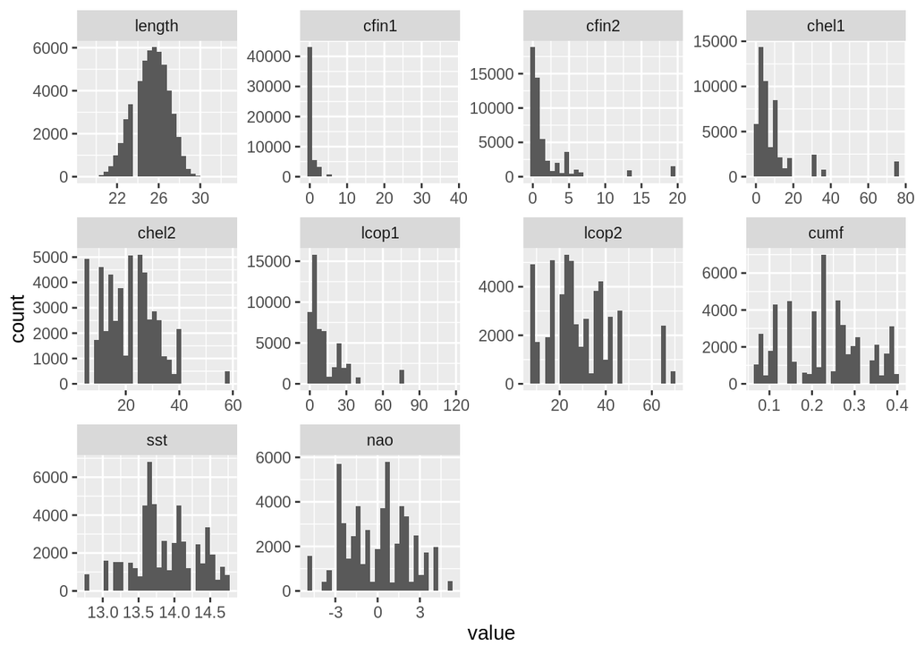

```r
ggplot(data = d, aes(x = value)) +
  facet_wrap(~variable, scales = "free") +
  geom_histogram()
```

```r
d <- melt(data %>% select(c("xmonth", "fbar", "recr", "totaln", "sal")))
```

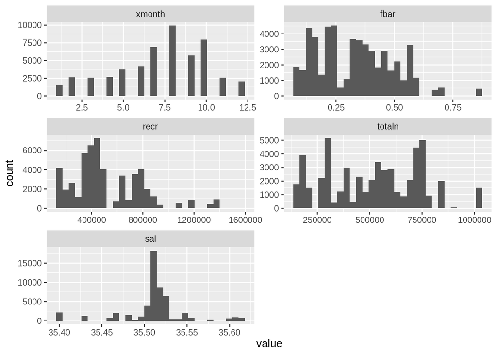

```r
ggplot(data = d, aes(x = value)) +
  facet_wrap(~variable, scales = "free", ncol = 2) +
  geom_histogram()
```

```r
ggplot.corr <- function(data, lag.max = 24, ci = 0.95, large.sample.size = TRUE, horizontal = TRUE,...) {

  require(ggplot2)
  require(dplyr)
  require(cowplot)

  if(horizontal == TRUE) {numofrow <- 1} else {numofrow <- 2}

  list.acf <- acf(data, lag.max = lag.max, type = "correlation", plot = FALSE)
  N <- as.numeric(list.acf$n.used)
  df1 <- data.frame(lag = list.acf$lag, acf = list.acf$acf)
  df1$lag.acf <- dplyr::lag(df1$acf, default = 0)
  df1$lag.acf[2] <- 0
  df1$lag.acf.cumsum <- cumsum((df1$lag.acf)^2)
  df1$acfstd <- sqrt(1/N * (1 + 2 * df1$lag.acf.cumsum))
  df1$acfstd[1] <- 0
  df1 <- select(df1, lag, acf, acfstd)

  list.pacf <- acf(sunspot.year, lag.max = lag.max, type = "partial", plot = FALSE)
  df2 <- data.frame(lag = list.pacf$lag,pacf = list.pacf$acf)
  df2$pacfstd <- sqrt(1/N)

  if(large.sample.size == TRUE) {
    plot.acf <- ggplot(data = df1, aes( x = lag, y = acf)) +
      geom_area(aes(x = lag, y = qnorm((1+ci)/2)*acfstd), fill = "#B9CFE7") +
      geom_area(aes(x = lag, y = -qnorm((1+ci)/2)*acfstd), fill = "#B9CFE7") +
      geom_col(fill = "#4373B6", width = 0.7) +
      scale_x_continuous(breaks = seq(0,max(df1$lag),6)) +
      scale_y_continuous(name = element_blank(),
                         limits = c(min(df1$acf,df2$pacf),1)) +
      ggtitle("ACF") +
      theme_bw()

    plot.pacf <- ggplot(data = df2, aes(x = lag, y = pacf)) +
      geom_area(aes(x = lag, y = qnorm((1+ci)/2)*pacfstd), fill = "#B9CFE7") +
      geom_area(aes(x = lag, y = -qnorm((1+ci)/2)*pacfstd), fill = "#B9CFE7") +
      geom_col(fill = "#4373B6", width = 0.7) +
      scale_x_continuous(breaks = seq(0,max(df2$lag, na.rm = TRUE),6)) +
      scale_y_continuous(name = element_blank(),
                         limits = c(min(df1$acf,df2$pacf),1)) +
      ggtitle("PACF") +
      theme_bw()
  }
  else {
    plot.acf <- ggplot(data = df1, aes( x = lag, y = acf)) +
      geom_col(fill = "#4373B6", width = 0.7) +
      geom_hline(yintercept = qnorm((1+ci)/2)/sqrt(N),
                 colour = "sandybrown",
                 linetype = "dashed") +
      geom_hline(yintercept = - qnorm((1+ci)/2)/sqrt(N),
                 colour = "sandybrown",
                 linetype = "dashed") +
      scale_x_continuous(breaks = seq(0,max(df1$lag),6)) +
      scale_y_continuous(name = element_blank(),
                         limits = c(min(df1$acf,df2$pacf),1)) +
      ggtitle("ACF") +
      theme_bw()

    plot.pacf <- ggplot(data = df2, aes(x = lag, y = pacf)) +
      geom_col(fill = "#4373B6", width = 0.7) +
      geom_hline(yintercept = qnorm((1+ci)/2)/sqrt(N),
                 colour = "sandybrown",
                 linetype = "dashed") +
      geom_hline(yintercept = - qnorm((1+ci)/2)/sqrt(N),
                 colour = "sandybrown",
                 linetype = "dashed") +
      scale_x_continuous(breaks = seq(0,max(df2$lag, na.rm = TRUE),6)) +
      scale_y_continuous(name = element_blank(),
                         limits = c(min(df1$acf,df2$pacf),1)) +
      ggtitle("PACF") +
      theme_bw()
  }
  cowplot::plot_grid(plot.acf, plot.pacf, nrow = numofrow)
}
```

### Badanie korelacji atrybutów

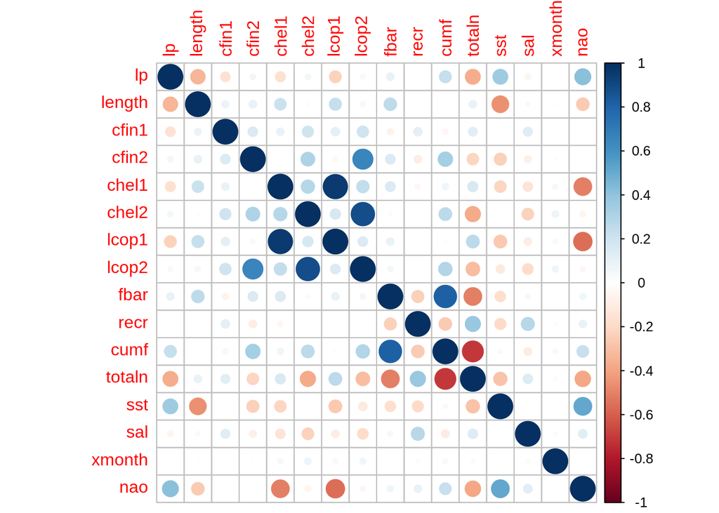

```r
cor_mat <- data[, 1:ncol(data)]
cor_mat = cor(cor_mat)
corrplot(cor_mat)
```

Macierz korelacji pokazuje, silną zależność liniową następujących par atrybutów

- chel1, lcop1
- chel2, lcop2
- cumf, fbar
- cumf, totaln

Może to być przesłanka do usunięcia niektórych atrybutów ze zbioru w celu poprawienia predykcji.

Dodatkowo w poniższej części zaprezentowano wykresy zależności długości ryby od wartości poszczególnych atrybutów. Niestety nie zaobserowano żadnej oczywistej zależności.

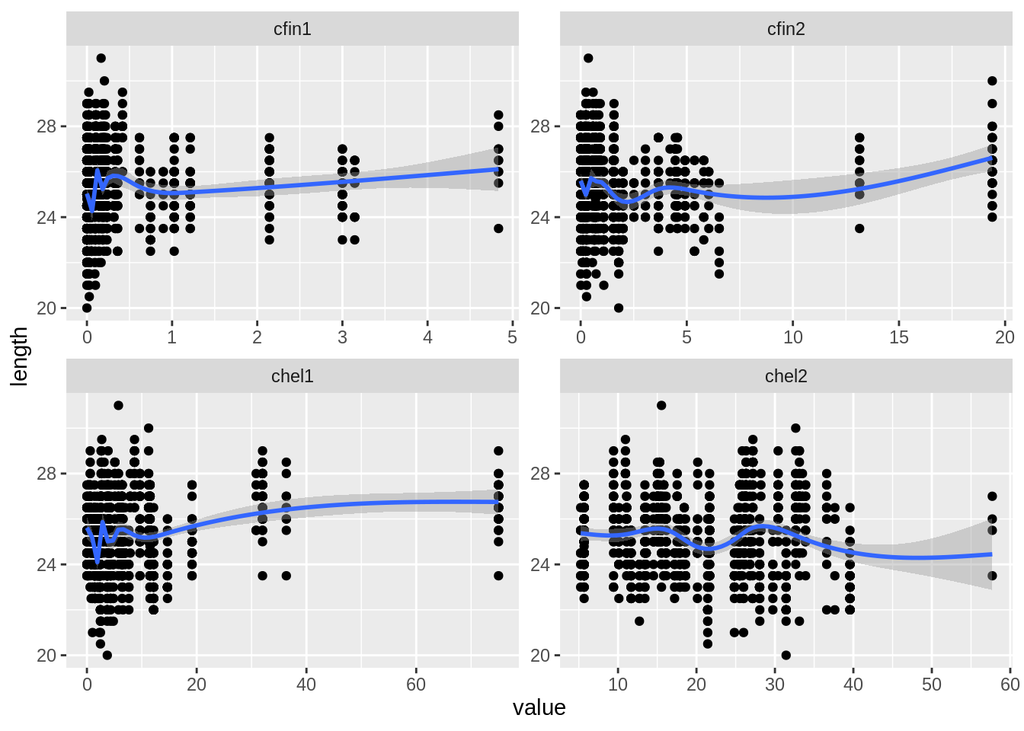

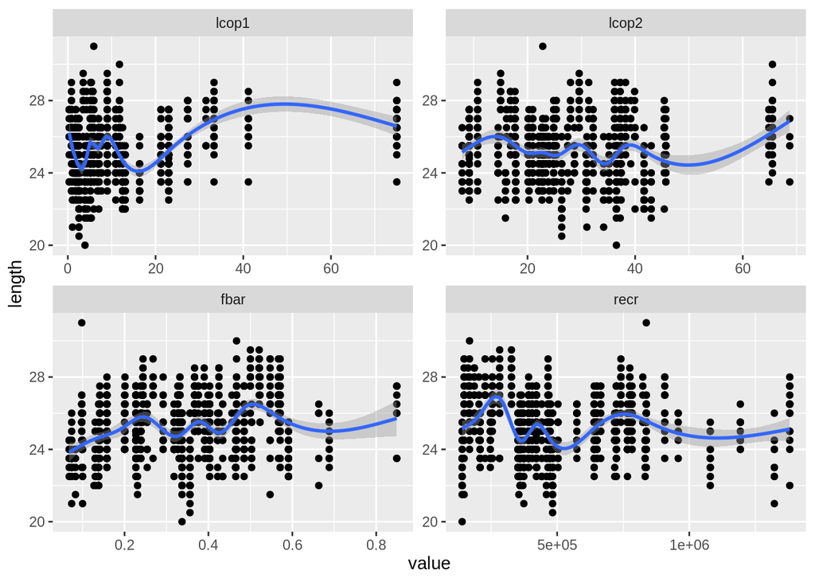

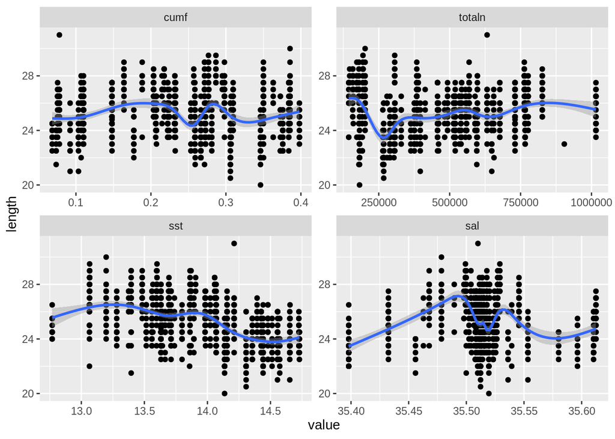

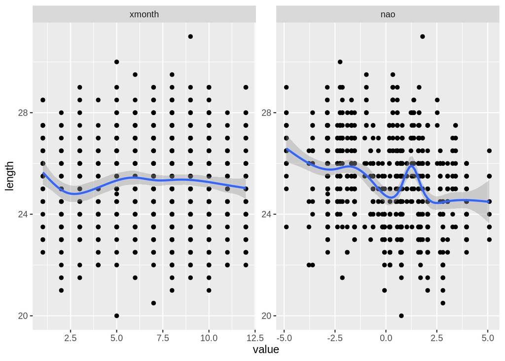

```r
sampled_data <- data[sample(nrow(data), 1000),]
length_base <- sampled_data %>% pull(var = "length")

for (attr in list(c("cfin1", "cfin2", "chel1", "chel2"),
                  c("lcop1", "lcop2", "fbar",  "recr"),
                  c("cumf", "totaln", "sst", "sal"),
                  c("xmonth", "nao"))) {
  d <- melt(sampled_data %>% select(attr))

  length <- rep_len(length_base, length.out = nrow(d))
  d %>% add_column(length)

  print(
    ggplot(data = d, aes(x = value, y = length)) +
      facet_wrap(~variable, scales = "free", ncol = 2) +
      geom_point() +
      geom_smooth()
  )
}
```

### Animacja

```r
sizes <- toJSON(sampled_data$length)
n  <- 1000
```

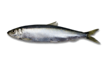

### Podział zbioru na zbiory treningowy, validacyjny oraz testowy

```r
idx <- createDataPartition(data$length, p=0.8, list=F)

data_nolp <- data %>% select(-c("lp"))

train_ds <- data_nolp[idx, ]
test_ds <- data_nolp[-idx, ]

idx <- createDataPartition(train_ds$length, p=0.8, list=F)

valid_ds <- train_ds[-idx, ]
train_ds <- train_ds[idx, ]
```

### Pomiar metryk

```r
# Compute R^2 from true and predicted values
eval_results <- function(true, predicted, df) {
  SSE <- sum((predicted - true)^2)
  SST <- sum((true - mean(true))^2)
  R_square <- 1 - SSE / SST
  RMSE = sqrt(SSE/nrow(df))


  # Model performance metrics
data.frame(
  RMSE = RMSE,
  Rsquare = R_square
)

}
```

### Skalowanie wartości atrybutów

Jest ono potrzebne dla poprawnego działania zastosowanego rozwinięcia modelu liniowego.

```r
col_names <- colnames(train_ds)
to_be_preprocessed <- col_names[!(col_names %in% c("length"))] #

pre_proc_val  <- preProcess(train_ds[, to_be_preprocessed], method = c("center", "scale"))
train_ds[, to_be_preprocessed] = predict(pre_proc_val, train_ds[, to_be_preprocessed])
valid_ds[, to_be_preprocessed] = predict(pre_proc_val, valid_ds[, to_be_preprocessed])
test_ds[, to_be_preprocessed] = predict(pre_proc_val, test_ds[, to_be_preprocessed])

summary(train_ds)
```

```
##      length         cfin1             cfin2              chel1
##  Min.   :19.0   Min.   :-0.4515   Min.   :-0.54292   Min.   :-0.69823
##  1st Qu.:24.0   1st Qu.:-0.4515   1st Qu.:-0.46826   1st Qu.:-0.52767
##  Median :25.5   Median :-0.3387   Median :-0.35450   Median :-0.30097
##  Mean   :25.3   Mean   : 0.0000   Mean   : 0.00000   Mean   : 0.00000
##  3rd Qu.:26.5   3rd Qu.:-0.1133   3rd Qu.:-0.06093   3rd Qu.: 0.09628
##  Max.   :32.5   Max.   :37.7559   Max.   : 4.66916   Max.   : 4.48340
##      chel2              lcop1             lcop2              fbar
##  Min.   :-1.59373   Min.   :-0.8285   Min.   :-1.4823   Min.   :-1.633363
##  1st Qu.:-0.77647   1st Qu.:-0.6812   1st Qu.:-0.7642   1st Qu.:-0.644761
##  Median : 0.02282   Median :-0.3838   Median :-0.2559   Median : 0.008089
##  Mean   : 0.00000   Mean   : 0.0000   Mean   : 0.0000   Mean   : 0.000000
##  3rd Qu.: 0.59741   3rd Qu.: 0.5470   3rd Qu.: 0.6362   3rd Qu.: 0.835033
##  Max.   : 3.64264   Max.   : 6.7496   Max.   : 2.9076   Max.   : 3.222599
##       recr              cumf              totaln             sst
##  Min.   :-1.3973   Min.   :-1.74170   Min.   :-1.6703   Min.   :-2.5268
##  1st Qu.:-0.5890   1st Qu.:-0.88110   1st Qu.:-0.9408   1st Qu.:-0.6242
##  Median :-0.3632   Median : 0.02317   Median : 0.1110   Median :-0.1693
##  Mean   : 0.0000   Mean   : 0.00000   Mean   : 0.0000   Mean   : 0.0000
##  3rd Qu.: 0.7515   3rd Qu.: 0.73656   3rd Qu.: 0.9705   3rd Qu.: 0.6482
##  Max.   : 3.8506   Max.   : 1.81524   Max.   : 2.2554   Max.   : 1.9619
##       sal               xmonth             nao
##  Min.   :-2.99561   Min.   :-2.2813   Min.   :-2.1223
##  1st Qu.:-0.04990   1st Qu.:-0.4625   1st Qu.:-0.7935
##  Median : 0.07265   Median : 0.2651   Median : 0.1398
##  Mean   : 0.00000   Mean   : 0.0000   Mean   : 0.0000
##  3rd Qu.: 0.28159   3rd Qu.: 0.6288   3rd Qu.: 0.7752
##  Max.   : 2.75855   Max.   : 1.7202   Max.   : 2.3084
```

### Regresja modelem liniowym

```r
linear_model <- lm(length ~ ., data = train_ds)
print(linear_model)
```

```
##
## Call:
## lm(formula = length ~ ., data = train_ds)
##
## Coefficients:
## (Intercept)        cfin1        cfin2        chel1        chel2        lcop1
##    25.30202      0.12909      0.06426     -0.13119     -0.07581      0.30616
##       lcop2         fbar         recr         cumf       totaln          sst
##     0.19048      0.99582     -0.09861     -0.97370     -0.15051     -0.54100
##         sal       xmonth          nao
##    -0.02298      0.02136      0.05676
```

```r
summary(linear_model)
```

```
##
## Call:
## lm(formula = length ~ ., data = train_ds)
##
## Residuals:
##     Min      1Q  Median      3Q     Max
## -7.5380 -0.9398  0.0068  0.9316  6.9405
##
## Coefficients:
##              Estimate Std. Error  t value Pr(>|t|)
## (Intercept) 25.302023   0.007427 3406.886  < 2e-16 ***
## cfin1        0.129095   0.008311   15.533  < 2e-16 ***
## cfin2        0.064262   0.017185    3.740 0.000185 ***
## chel1       -0.131190   0.029749   -4.410 1.04e-05 ***
## chel2       -0.075811   0.028877   -2.625 0.008662 **
## lcop1        0.306164   0.029235   10.473  < 2e-16 ***
## lcop2        0.190479   0.033178    5.741 9.49e-09 ***
## fbar         0.995820   0.017069   58.342  < 2e-16 ***
## recr        -0.098608   0.009489  -10.392  < 2e-16 ***
## cumf        -0.973699   0.018398  -52.924  < 2e-16 ***
## totaln      -0.150514   0.014795  -10.173  < 2e-16 ***
## sst         -0.541004   0.010933  -49.485  < 2e-16 ***
## sal         -0.022977   0.008402   -2.735 0.006245 **
## xmonth       0.021356   0.007462    2.862 0.004211 **
## nao          0.056758   0.011800    4.810 1.52e-06 ***
## ---
## Signif. codes:  0 '***' 0.001 '**' 0.01 '*' 0.05 '.' 0.1 ' ' 1
##
## Residual standard error: 1.362 on 33640 degrees of freedom
## Multiple R-squared:  0.3225, Adjusted R-squared:  0.3222
## F-statistic:  1144 on 14 and 33640 DF,  p-value: < 2.2e-16
```

```r
# Train
predictions_train <- predict(linear_model, train_ds)
eval_results(train_ds$length, predictions_train, train_ds)
```

```
##       RMSE  Rsquare
## 1 1.362152 0.322472
```

```r
# Valid
predictions_valid <- predict(linear_model, valid_ds)
eval_results(valid_ds$length, predictions_valid, valid_ds)
```

```
##       RMSE   Rsquare
## 1 1.362302 0.3148242
```

```r
linear_model_v2 <- glm(length ~ . +sst * nao + nao * chel2 +fbar * cumf -xmonth -cfin2 -sal -totaln, data = train_ds)

summary(linear_model_v2)
```

```
##
## Call:
## glm(formula = length ~ . + sst * nao + nao * chel2 + fbar * cumf -
##     xmonth - cfin2 - sal - totaln, data = train_ds)
##
## Deviance Residuals:
##     Min       1Q   Median       3Q      Max
## -6.0446  -0.9206  -0.0177   0.9533   7.0794
##
## Coefficients:
##              Estimate Std. Error  t value Pr(>|t|)
## (Intercept) 25.496277   0.011830 2155.237   <2e-16 ***
## cfin1        0.079080   0.008053    9.820   <2e-16 ***
## chel1       -0.273849   0.031516   -8.689   <2e-16 ***
## chel2       -0.231733   0.018191  -12.739   <2e-16 ***
## lcop1        0.370071   0.031363   11.799   <2e-16 ***
## lcop2        0.420694   0.018625   22.588   <2e-16 ***
## fbar         1.084035   0.018436   58.800   <2e-16 ***
## recr        -0.167032   0.008805  -18.970   <2e-16 ***
## cumf        -1.001786   0.017790  -56.311   <2e-16 ***
## sst         -0.437954   0.011812  -37.076   <2e-16 ***
## nao          0.010336   0.012320    0.839    0.401
## sst:nao     -0.162369   0.009621  -16.876   <2e-16 ***
## chel2:nao   -0.166310   0.009291  -17.899   <2e-16 ***
## fbar:cumf   -0.148538   0.009580  -15.505   <2e-16 ***
## ---
## Signif. codes:  0 '***' 0.001 '**' 0.01 '*' 0.05 '.' 0.1 ' ' 1
##
## (Dispersion parameter for gaussian family taken to be 1.827183)
##
##     Null deviance: 92167  on 33654  degrees of freedom
## Residual deviance: 61468  on 33641  degrees of freedom
## AIC: 115811
##
## Number of Fisher Scoring iterations: 2
```

```r
# Train
predictions_train <- predict(linear_model_v2, train_ds)
eval_results(train_ds$length, predictions_train, train_ds)
```

```
##       RMSE   Rsquare
## 1 1.351452 0.3330745
```

```r
# Valid
predictions_valid <- predict(linear_model_v2, valid_ds)
eval_results(valid_ds$length, predictions_valid, valid_ds)
```

```
##       RMSE   Rsquare
## 1 1.351831 0.3253162
```